# Part I - Ford GoBike System Exploration

## Introduction

The Ford GoBike System dataset contains bike trip data from the San Francisco Bay Area. It includes information on trip duration, start and end locations, and user type. This data can help explore bike usage patterns in the city.

## Preliminary Wrangling

```python
# Importing essential libraries
import numpy as np
import pandas as pd
import matplotlib.pyplot as plt
import seaborn as sns
```

#### Loading the Ford GoBike dataset to explore bike usage patterns and trip trends.

```python
df = pd.read_csv('201902-fordgobike-tripdata.csv')
```

```python
df.head()
```

|  | duration_sec | start_time | end_time | start_station_id | start_station_name | start_station_latitude | start_station_longitude | end_station_id | end_station_name | end_station_latitude | end_station_longitude | bike_id | user_type | member_birth_year | member_gender | bike_share_for_all_trip |
| --- | --- | --- | --- | --- | --- | --- | --- | --- | --- | --- | --- | --- | --- | --- | --- | --- |
| 0 | 52185 | 2019-02-28 17:32:10.1450 | 2019-03-01 08:01:55.9750 | 21.0 | Montgomery St BART Station (Market St at 2nd St) | 37.789625 | -122.400811 | 13.0 | Commercial St at Montgomery St | 37.794231 | -122.402923 | 4902 | Customer | 1984.0 | Male | No |
| 1 | 42521 | 2019-02-28 18:53:21.7890 | 2019-03-01 06:42:03.0560 | 23.0 | The Embarcadero at Steuart St | 37.791464 | -122.391034 | 81.0 | Berry St at 4th St | 37.775880 | -122.393170 | 2535 | Customer | NaN | NaN | No |
| 2 | 61854 | 2019-02-28 12:13:13.2180 | 2019-03-01 05:24:08.1460 | 86.0 | Market St at Dolores St | 37.769305 | -122.426826 | 3.0 | Powell St BART Station (Market St at 4th St) | 37.786375 | -122.404904 | 5905 | Customer | 1972.0 | Male | No |
| 3 | 36490 | 2019-02-28 17:54:26.0100 | 2019-03-01 04:02:36.8420 | 375.0 | Grove St at Masonic Ave | 37.774836 | -122.446546 | 70.0 | Central Ave at Fell St | 37.773311 | -122.444293 | 6638 | Subscriber | 1989.0 | Other | No |
| 4 | 1585 | 2019-02-28 23:54:18.5490 | 2019-03-01 00:20:44.0740 | 7.0 | Frank H Ogawa Plaza | 37.804562 | -122.271738 | 222.0 | 10th Ave at E 15th St | 37.792714 | -122.248780 | 4898 | Subscriber | 1974.0 | Male | Yes |

```python
df.info()
```

```
<class 'pandas.core.frame.DataFrame'>
RangeIndex: 183412 entries, 0 to 183411
Data columns (total 16 columns):
 #   Column                   Non-Null Count   Dtype
---  ------                   --------------   -----
 0   duration_sec             183412 non-null  int64
 1   start_time               183412 non-null  object
 2   end_time                 183412 non-null  object
 3   start_station_id         183215 non-null  float64
 4   start_station_name       183215 non-null  object
 5   start_station_latitude   183412 non-null  float64
 6   start_station_longitude  183412 non-null  float64
 7   end_station_id           183215 non-null  float64
 8   end_station_name         183215 non-null  object
 9   end_station_latitude     183412 non-null  float64
 10  end_station_longitude    183412 non-null  float64
 11  bike_id                  183412 non-null  int64
 12  user_type                183412 non-null  object
 13  member_birth_year        175147 non-null  float64
 14  member_gender            175147 non-null  object
 15  bike_share_for_all_trip  183412 non-null  object
dtypes: float64(7), int64(2), object(7)
memory usage: 22.4+ MB
```

```python
df.dtypes
```

```
duration_sec                 int64
start_time                  object
end_time                    object
start_station_id           float64
start_station_name          object
start_station_latitude     float64
start_station_longitude    float64
end_station_id             float64
end_station_name            object
end_station_latitude       float64
end_station_longitude      float64
bike_id                      int64
user_type                   object
member_birth_year          float64
member_gender               object
bike_share_for_all_trip     object
dtype: object
```

### Converting columns' data types

> Define the columns that need to be converted and their types

```python
conversion_dict = {
    'start_time': 'datetime',
    'end_time': 'datetime',
    'start_station_id': 'int',
    'end_station_id': 'int',
    'member_birth_year': 'int',
    'user_type': 'category',
    'member_gender': 'category',
    'bike_share_for_all_trip': 'bool'
}
```

> Loop through the dictionary and convert each column

```python
def convert_data_types(df, conversion_dict):
    for column, dtype in conversion_dict.items():
        if dtype == 'datetime':
            df[column] = pd.to_datetime(df[column], errors='coerce')
        elif dtype == 'category':
            df[column] = df[column].astype('category')
        elif dtype == 'int64':
            df[column] = df[column].astype('int64')
    return df
```

```python
df['member_gender'] = df['member_gender'].astype(str)
```

```python
df = convert_data_types(df, conversion_dict)
```

```python
# check the updated dataframe types
df.dtypes
```

```
duration_sec                        int64
start_time                 datetime64[ns]
end_time                   datetime64[ns]
start_station_id                  float64
start_station_name                 object
start_station_latitude            float64
start_station_longitude           float64
end_station_id                    float64
end_station_name                   object
end_station_latitude              float64
end_station_longitude             float64
bike_id                             int64
user_type                        category
member_birth_year                 float64
member_gender                    category
bike_share_for_all_trip            object
dtype: object
```

```python
df.isna().sum()
```

```
duration_sec                  0
start_time                    0
end_time                      0
start_station_id            197
start_station_name          197
start_station_latitude        0
start_station_longitude       0
end_station_id              197
end_station_name            197
end_station_latitude          0
end_station_longitude         0
bike_id                       0
user_type                     0
member_birth_year          8265
member_gender                 0
bike_share_for_all_trip       0
dtype: int64
```

# handling missing values

```python
def handle_missing_values(df):
    df.dropna(subset=['start_station_id', 'end_station_id'], inplace=True)
    df['member_birth_year'].fillna(df['member_birth_year'].median(), inplace=True)
    df['member_gender'] = df['member_gender'].cat.add_categories('Unknown')
    df['member_gender'].fillna('Unknown', inplace=True)
    return df

# Usage
df = handle_missing_values(df)
```

```python
df.isna().sum()
```

```
duration_sec               0
start_time                 0
end_time                   0
start_station_id           0
start_station_name         0
start_station_latitude     0
start_station_longitude    0
end_station_id             0
end_station_name           0
end_station_latitude       0
end_station_longitude      0
bike_id                    0
user_type                  0
member_birth_year          0
member_gender              0
bike_share_for_all_trip    0
dtype: int64
```

```python
df.shape
```

```
(183215, 16)
```

```python
df.describe()
```

|  | duration_sec | start_time | end_time | start_station_id | start_station_latitude | start_station_longitude | end_station_id | end_station_latitude | end_station_longitude | bike_id | member_birth_year |
| --- | --- | --- | --- | --- | --- | --- | --- | --- | --- | --- | --- |
| count | 183215.000000 | 183215 | 183215 | 183215.000000 | 183215.000000 | 183215.000000 | 183215.000000 | 183215.000000 | 183215.000000 | 183215.000000 | 183215.000000 |
| mean | 725.902017 | 2019-02-15 21:04:31.445224704 | 2019-02-15 21:16:37.846335744 | 138.590427 | 37.771615 | -122.353104 | 136.249123 | 37.771820 | -122.352689 | 4473.218792 | 1984.902213 |
| min | 61.000000 | 2019-02-01 00:00:20.636000 | 2019-02-01 00:04:52.058000 | 3.000000 | 37.317298 | -122.453704 | 3.000000 | 37.317298 | -122.453704 | 11.000000 | 1878.000000 |
| 25% | 325.000000 | 2019-02-08 08:29:44.952499968 | 2019-02-08 08:40:10.263500032 | 47.000000 | 37.770407 | -122.412408 | 44.000000 | 37.770407 | -122.411726 | 3777.000000 | 1981.000000 |
| 50% | 514.000000 | 2019-02-15 22:47:27.054000128 | 2019-02-15 23:02:10.630000128 | 104.000000 | 37.780760 | -122.398285 | 100.000000 | 37.781010 | -122.398279 | 4958.000000 | 1987.000000 |
| 75% | 796.000000 | 2019-02-22 10:59:11.464000 | 2019-02-22 11:11:26.949000192 | 239.000000 | 37.797280 | -122.287180 | 235.000000 | 37.797320 | -122.288665 | 5503.000000 | 1992.000000 |
| max | 85444.000000 | 2019-02-28 23:59:18.548000 | 2019-03-01 08:01:55.975000 | 398.000000 | 37.880222 | -121.874119 | 398.000000 | 37.880222 | -121.874119 | 6645.000000 | 2001.000000 |
| std | 1795.078654 | NaN | NaN | 111.778864 | 0.098914 | 0.116387 | 111.515131 | 0.098819 | 0.115961 | 1665.249372 | 9.898425 |

### What is the structure of your dataset?

The dataset contains 183,412 records with 16 features including:

1. **duration_sec**: the duration of the trip in seconds
2. **start_time**: the date and time when the trip started
3. **end_time**: the date and time when the trip ended
4. **start_station_id**: The unique identifier for the station where the trip began
5. **start_station_name**: the name of the station where the trip began
6. **start_station_latitude**: The latitude coordinate of the start station
7. **start_station_longitude**: The longitude coordinate of the start station
8. **end_station_id**: the unique identifier for the station where the trip ended
9. **end_station_name**: The name of the station where the trip ended
10. **end_station_latitude**: The latitude coordinate of the end station
11. **end_station_longitude**: The longitude coordinate of the end station
12. **bike_id**: The unique identifier for the bike used during the trip
13. **user_type**: The type of user: "Subscriber" for members or "Customer" for casual users
14. **member_birth_year**: The birth year of the user
15. **member_gender**: The gender of the user
16. **bike_share_for_all_trip**: Indicates whether the trip was part of the "Bike Share for All" program which offers discounted memberships to low income residents

> Column descriptions were adapted from Zhou (n.d.), who documented the dataset in the GitHub repository Bike System Data Exploration[https://github.com/chefZau/Bike-System-Data-Exploration] ,with additional enhancements to improve clarity and detail.

### What is/are the main feature(s) of interest in your dataset?

The main features of interest are the trip duration, start and end stations, user type, and start time, as they provide key insights into bike usage patterns

### What features in the dataset do you think will help support your investigation into your feature(s) of interest?

Features like end time, member birth year, gender, and bike-sharing status will help support the investigation by providing context on user demographics and trip patterns

## Univariate Exploration

#### Trip Duration Histogram

##### **1st Question:** How is the distribution of trip durations? Are there any unusual patterns?

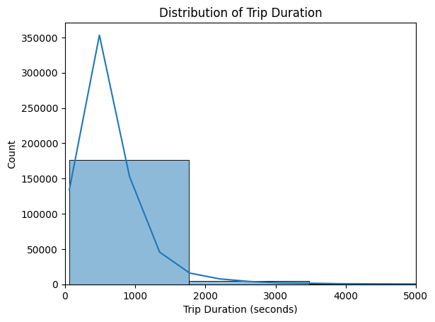

```python
sns.histplot(df['duration_sec'], bins=50, kde=True)
plt.xlim(0, 5000)  # limiting to 5000 sec for better visibility
plt.xlabel('Trip Duration (seconds)')
plt.ylabel('Count')
plt.title('Distribution of Trip Duration')
```

- Most trips last under 1000 seconds (~16 minutes)
- There is a long tail, meaning some trips last much longer
- Some extreme outliers exceed 5000 seconds (~83 minutes)

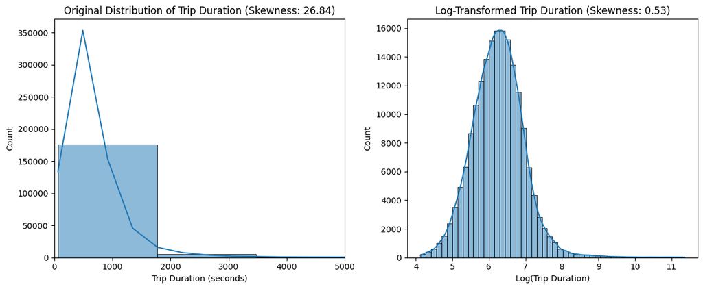

```python
# Check for skewness
skewness = df['duration_sec'].skew()

# Plot original distribution
plt.figure(figsize=(12, 5))
plt.subplot(1, 2, 1)
sns.histplot(df['duration_sec'], bins=50, kde=True)
plt.xlim(0, 5000)  # limiting to 5000 sec for better visibility
plt.xlabel('Trip Duration (seconds)')
plt.ylabel('Count')
plt.title(f'Original Distribution of Trip Duration (Skewness: {skewness:.2f})')

# If the skewness is high, apply log transformation
if skewness > 1:
    df['log_duration_sec'] = np.log1p(df['duration_sec'])  # log(1 + x) to handle zero values
    log_skewness = df['log_duration_sec'].skew()

    # Plot log-transformed distribution
    plt.subplot(1, 2, 2)
    sns.histplot(df['log_duration_sec'], bins=50, kde=True)
    plt.xlabel('Log(Trip Duration)')
    plt.ylabel('Count')
    plt.title(f'Log-Transformed Trip Duration (Skewness: {log_skewness:.2f})')

plt.tight_layout()
plt.show()
```

- Due to the high right skew, a log transformation was applied to normalize the distribution, making it closer to a bell-shaped curve.

#### Member Birth Year Histogram

##### **2nd Question:** What is the age distribution of bike riders? Are there unusual age patterns?

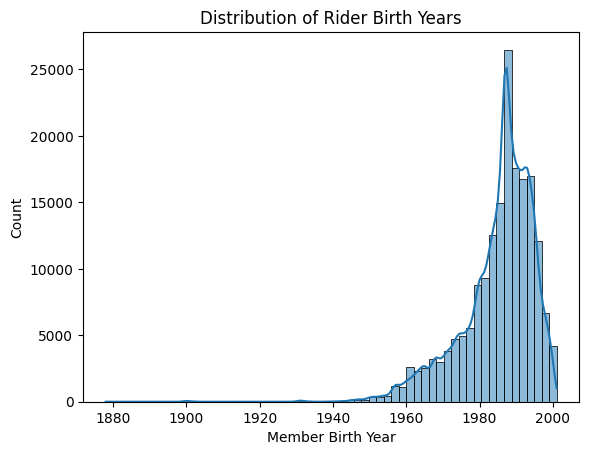

```python
sns.histplot(df['member_birth_year'].dropna(), bins=60, kde=True)
plt.xlabel('Member Birth Year')
plt.ylabel('Count')
plt.title('Distribution of Rider Birth Years')
```

- Most riders were born between **1980 and 2000**.
- A few birth years are extreme (e.g., 1900 or earlier), i think it's a data entry error

#### Bike Share for All Trip Distribution

##### **3rd Question:** How many users are part of the Bike Share for All program?

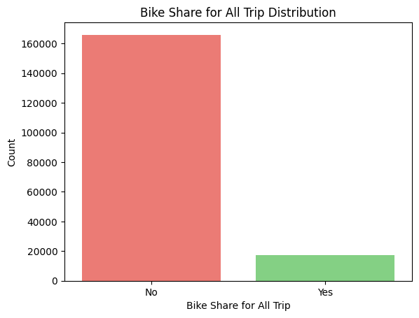

```python
sns.countplot(x=df['bike_share_for_all_trip'],
              palette=["#ff6961", "#77dd77"],  # Muted red and muted green hex codes
              order=["No", "Yes"])
plt.xlabel('Bike Share for All Trip')
plt.ylabel('Count')
plt.title('Bike Share for All Trip Distribution')
plt.show()
```

#### User Type Count Plot

##### **4th Question:** What is the proportion of Subscribers vs. Customers?

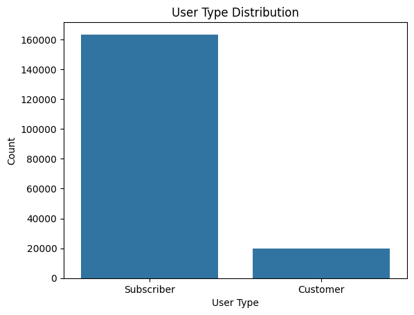

```python
order1 = df['user_type'].value_counts().index
sns.countplot(x=df['user_type'], color='tab:blue',order=order1)
plt.xlabel('User Type')
plt.ylabel('Count')
plt.title('User Type Distribution')
```

- Most users are **Subscribers**, meaning they use the service regularly.
- **Customers (occasional riders)** are far fewer in comparison.

#### Member Gender Bar Chart

##### **5th Question:** What is the gender distribution among bike riders?

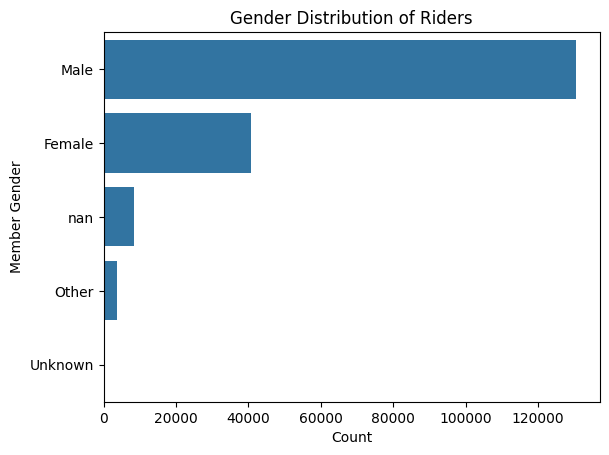

```python
order2 = df['member_gender'].value_counts().index

sns.countplot(y=df['member_gender'].dropna(), color="tab:blue", order=order2)
plt.ylabel('Member Gender')
plt.xlabel('Count')
plt.title('Gender Distribution of Riders')
```

- Majority of riders are **Male**, followed by **Female**.
- Some users selected "Other" as their gender.

### Discuss the distribution(s) of your variable(s) of interest. Were there any unusual points? Did you need to perform any transformations?

the trip duration distribution is highly right-skewed, with most trips lasting under 1000 seconds (~16 minutes) but some extending beyond 5000 seconds (~83 minutes). These long trips could be outliers, possibly due to unusual usage patterns or errors in trip logging. A log transformation could help visualize the data more effectively

The member birth year distribution shows that most users were born between 1980 and 2000, but there are some unrealistic values, such as birth years before 1900, which are likely data entry errors. These values may need to be removed or corrected

For categorical variables, the user type distribution is highly imbalanced, with far more subscribers than customers, indicating that most users are regular riders rather than occasional ones

The gender distribution is also skewed, with more male riders than female riders, which might indicate a demographic trend in bike usage

### Of the features you investigated, were there any unusual distributions? Did you perform any operations on the data to tidy, adjust, or change the form of the data? If so, why did you do this?

Yes some features had unusual distributions that required attention like: Trip Duration: Since the distribution is highly skewed, a log transformation could be applied to normalize the data and make trends more apparent.

Member Birth Year: Some values were implausibly old (before 1900), likely due to data entry errors. These would need to be cleaned or removed to avoid misleading analysis

Categorical Features (User Type, Bike Share Status, Gender): These distributions were mostly expected, but the imbalance in user type (subscribers vs. customers) might require resampling in certain analyses to prevent bias.

## Bivariate Exploration

#### 1st Question: Does age affect trip duration?

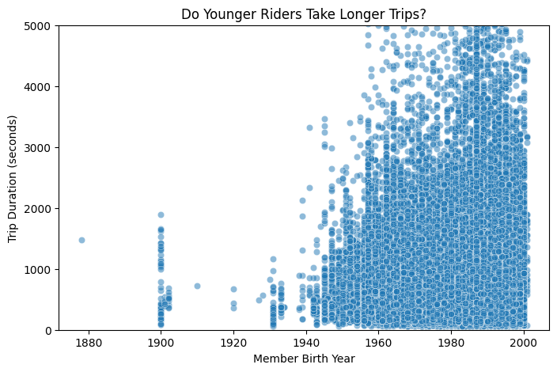

```python
# Scatter plot of member birth year vs. trip duration
plt.figure(figsize=(8, 5))
sns.scatterplot(x=df['member_birth_year'], y=df['duration_sec'], alpha=0.5)
plt.xlabel('Member Birth Year')
plt.ylabel('Trip Duration (seconds)')
plt.title('Do Younger Riders Take Longer Trips?')
plt.ylim(0, 5000)  # Limiting for better visibility
plt.show()
```

#### **2nd Question: How does trip duration vary across user types (Subscriber vs. Customer)?**

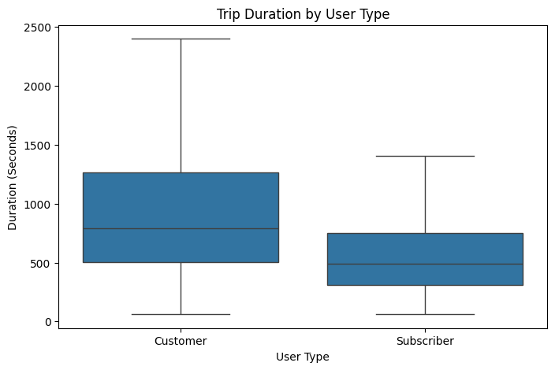

```python
# Box plot of trip duration by user type
plt.figure(figsize=(8, 5))
sns.boxplot(data=df, x="user_type", y="duration_sec", showfliers=False)
plt.title("Trip Duration by User Type")
plt.xlabel("User Type")
plt.ylabel("Duration (Seconds)")
plt.show()
```

- **Customers take longer trips** on average compared to **Subscribers**.
- **Subscribers have more consistent trip durations**, while customers have a wider range of trip lengths.
- Some **outliers** exist, particularly for customers.

#### **3rd Question: What’s the Peak Usage Pattern for Each Day of the Week?**

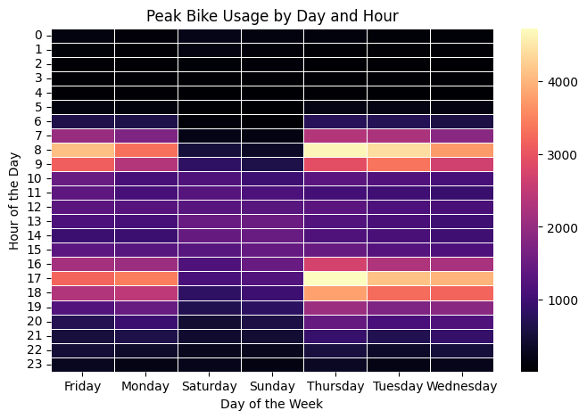

```python
# Heatmap of bike usage by day and hour
plt.figure(figsize=(8, 5))
df['weekday'] = df['start_time'].dt.day_name()
df['hour'] = df['start_time'].dt.hour
usage_pattern = df.pivot_table(index='hour', columns='weekday', aggfunc='size', fill_value=0)

sns.heatmap(usage_pattern, cmap="magma", annot=False, linewidths=0.5)
plt.xlabel('Day of the Week')
plt.ylabel('Hour of the Day')
plt.title('Peak Bike Usage by Day and Hour')
plt.show()
```

- Weekday peaks appear at morning and evening rush hours (8 AM & 5-6 PM).
- Weekends have higher afternoon activity (12 PM - 4 PM).
- Late-night rides are uncommon, with usage dropping significantly after 10 PM.

#### **4th Question: How Does Average Trip Duration Change by Hour of the Day?**

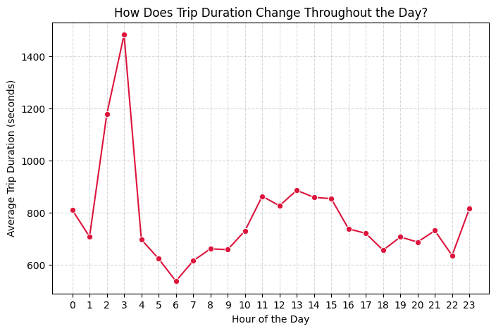

```python
# Line plot of average trip duration by hour of the day
plt.figure(figsize=(8, 5))
df['hour'] = df['start_time'].dt.hour
avg_duration_per_hour = df.groupby('hour')['duration_sec'].mean()

sns.lineplot(x=avg_duration_per_hour.index, y=avg_duration_per_hour.values, marker="o", color="crimson")
plt.xlabel('Hour of the Day')
plt.ylabel('Average Trip Duration (seconds)')
plt.title('How Does Trip Duration Change Throughout the Day?')
plt.xticks(range(0, 24))
plt.grid(True, linestyle='--', alpha=0.5)
plt.show()
```

- **Morning trips (6 AM - 9 AM) are relatively short**, suggesting people are rushing to work.
- **Midday and evening rides (12 PM - 7 PM) last longer**, likely due to casual and leisure rides.
- **Late-night trips (10 PM - 4 AM) are rare but tend to be longer**, possibly recreational.

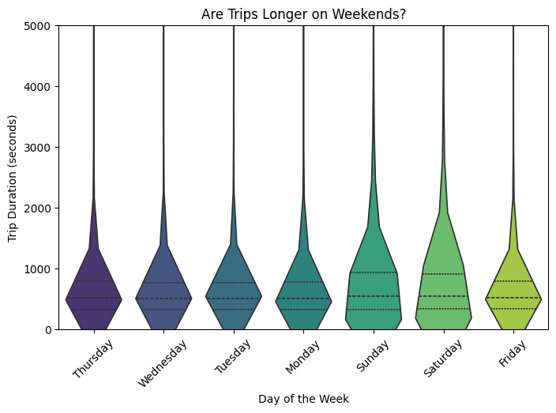

```python
# Violin plot of trip duration by day of the week
plt.figure(figsize=(8, 5))
sns.violinplot(x=df['start_time'].dt.day_name(), y=df['duration_sec'], inner="quartile", palette="viridis")
plt.xticks(rotation=45)
plt.xlabel('Day of the Week')
plt.ylabel('Trip Duration (seconds)')
plt.title('Are Trips Longer on Weekends?')
plt.ylim(0, 5000)  # Limiting for better visibility
plt.show()
```

- **Weekends (Saturday & Sunday) have a higher spread of trip durations**, meaning **longer trips** happen more frequently.
- **Weekdays show more consistency**, indicating that most weekday rides are likely **commutes**.
- **Saturday has the highest variation**, suggesting **leisure trips are more common** on this day.

### Did you observe any interesting relationships between the other features (not the main feature(s) of interest))?

No I didn't

## Multivariate Exploration

#### 1st question: How does ride duration vary by user type and time of day?

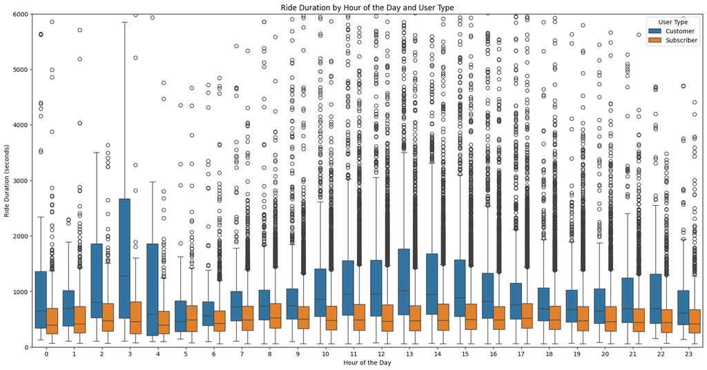

```python
# Extract the hour from the start_time column
df['start_hour'] = df['start_time'].dt.hour

plt.figure(figsize=(20, 10))
sns.boxplot(data=df, x='start_hour', y='duration_sec', hue='user_type')
plt.ylim(0, 6000)  # Limit y-axis to avoid extreme outliers
plt.xlabel('Hour of the Day')
plt.ylabel('Ride Duration (seconds)')
plt.title('Ride Duration by Hour of the Day and User Type')
plt.legend(title='User Type')
plt.show()
```

#### 2nd question : Do male and female users differ in trip duration?

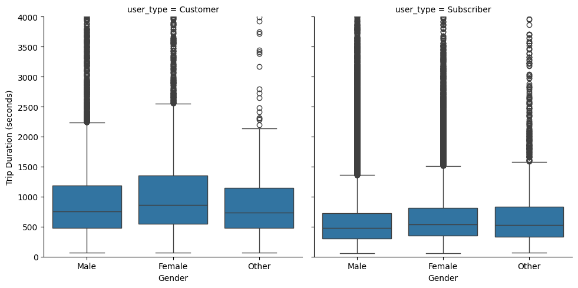

```python
g = sns.FacetGrid(df, col="user_type", height=5)
g.map(sns.boxplot, "member_gender", "duration_sec", order=["Male", "Female", "Other"])
g.set_ylabels("Trip Duration (seconds)")
g.set_xlabels("Gender")
plt.ylim(0, 4000)  # Removing extreme values
plt.show()
```

#### 3rd question: How does trip duration vary across different hours of the day for different user types?

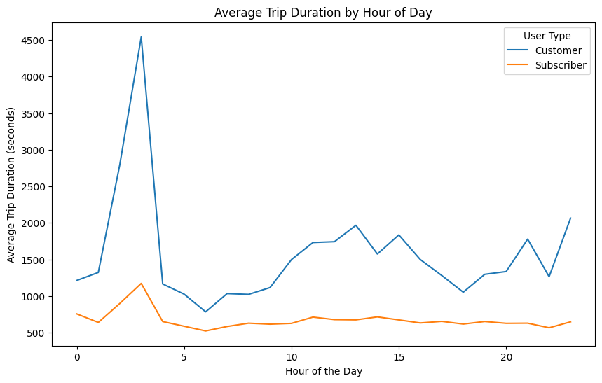

```python
plt.figure(figsize=(10, 6))
sns.lineplot(data=df.groupby(['start_hour', 'user_type'])['duration_sec'].mean().reset_index(),
			 x="start_hour", y="duration_sec", hue="user_type", ci=None)
plt.title("Average Trip Duration by Hour of Day")
plt.xlabel("Hour of the Day")
plt.ylabel("Average Trip Duration (seconds)")
plt.legend(title="User Type")
plt.show()
```

#### 4th question:How does the number of trips vary by day of the week and user type?

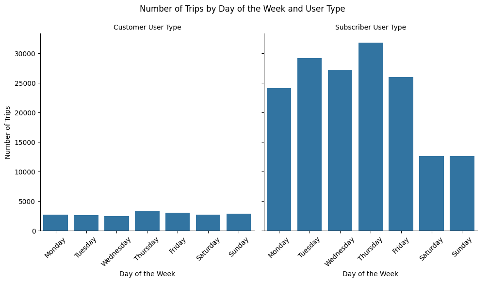

```python
# Extract day of the week from start_time
df['day_of_week'] = df['start_time'].dt.day_name()

# Facet Plot: Number of Trips by Day of the Week and User Type
g = sns.catplot(data=df, x='day_of_week', kind='count', col='user_type', order=['Monday', 'Tuesday', 'Wednesday', 'Thursday', 'Friday', 'Saturday', 'Sunday'])
g.set_axis_labels("Day of the Week", "Number of Trips")
g.set_titles("{col_name} User Type")
g.set_xticklabels(rotation=45)
plt.suptitle("Number of Trips by Day of the Week and User Type", y=1.05)
plt.show()
```

### Talk about some of the relationships you observed in this part of the investigation. Were there features that strengthened each other in terms of looking at your feature(s) of interest?

In this prt of the investigation, several relationships were observed that provided deeeeper insights into bike usage patterns. For instance, the relationship between ride duration and user type revealed that customers (casual riders) generally take longer trips compared to subscribers, who exhibit more consistent trip durations throughout the day. This distinction was further strengthened by analyzing trip durations across different times of the day, where it was evident that ride durations tend to be longer during early morning hours (before 6 AM) and late at night.

These Relationships collectively strengthen the understanding of how various factors such as user type, time of day, and demographics influence bike usage patterns.

### Were there any interesting or surprising interactions between features?

yes, there were several interesting and surprising interactions uncovered during the exploration. One notable finding was the difference in peak usage patterns between weekdays and weekends. Weekdays demonstrated clear peaks during morning and evening rush hours (8 AM and 5-6 PM), aligning with commuter behavior. In contrast, weekends showed higher activity levels in the afternoon (12 PM - 4 PM), suggesting that weekend trips are more likely to be recreational rather than work-related.

Another intriguing observation was the disparity in trip duration between subscribers and customers. Subscribers consistently took shorter trips with less variation, indicating regular commuting patterns, while customers exhibited longer and more varied trip durations, possibly due to leisure or recreational purposes.